# Modelling_Group_Project_R

MW, KV, LA, SD

November 27, 2017

# Group Project Question 1 - Lotka-Volterra Model

### Equations

Prey $dh/dt = b*H - a*P*H$

Predator $dP/dt = e*a*P*H - s*P$

### Initial Model

Below we load the required modules, set initial parameters, and use the function ode() to run our model.

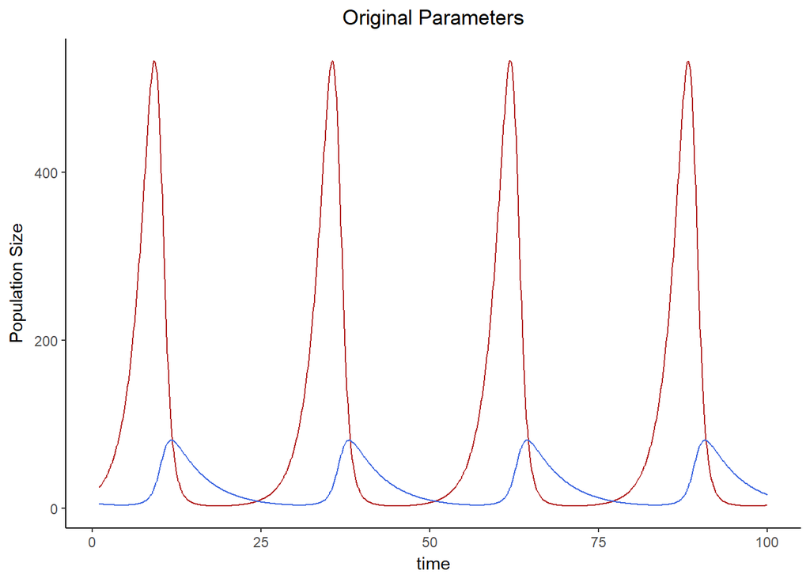

```r
# Load the deSolve package required for solving differential equations in R and ggplot2 package for graphing
library(deSolve)
library(ggplot2)
library(knitr)

# Create a custom function for simulating Lotka-Volterra Competition Model
predPreySim<-function(t,y,p){
  herbivore=y[1]
  carnivore=y[2]
  h_birthrate=p[1]
  c_attackrate=p[2]
  h_c_efficiency=p[3]
  c_death=p[4]
  dHerb_dt=(h_birthrate*herbivore)-(c_attackrate*carnivore*herbivore)
  dCarn_dt=(h_c_efficiency*c_attackrate*carnivore*herbivore)-(c_death*carnivore)
  return(list(c(dHerb_dt,dCarn_dt)))
}


# Set parameters, initial state variables, and simulation timepoints
y = c(25,5)
p = c(0.5,0.02,0.1,0.2)
times=seq(from=1,to=100,by=0.1)


# Simulate the model using ode
modelSim=ode(y=y,times=times,func=predPreySim,parms=p)
colnames(modelSim)[2] <- "herbivore"
colnames(modelSim)[3] <- "predator"

# Convert to datafrome for plotting purposes
modelSim2 <- as.data.frame(modelSim)

# plot simulation
ggplot(data=modelSim2,aes(x=time)) + geom_line(aes(y=herbivore), colour="firebrick") + geom_line(aes(y=predator),colour="royalblue")+theme_classic()+ylab("Population Size")+ggtitle("Original Parameters")+theme(plot.title = element_text(hjust = 0.5))
```

Initial summary of output below. How the parameters change will be determined by comparing results to above graph and summary below.

```r
#show result summary of the data frame
kable(summary(modelSim))
```

|  | herbivore | predator |
| --- | --- | --- |
| Min. | 2.642454 | 3.676633 |
| 1st Qu. | 4.364783 | 5.386827 |
| Median | 21.810086 | 15.707261 |
| Mean | 105.735381 | 26.002544 |
| 3rd Qu. | 141.380539 | 41.663795 |
| Max. | 533.347326 | 80.982968 |
| N | 991.000000 | 991.000000 |
| sd | 155.689454 | 24.543401 |

### Changing the number of prey

Adjust initial parameters. Change prey from 25 to 125.

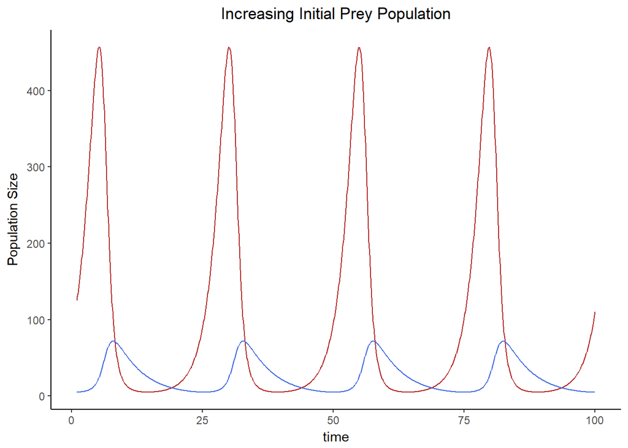

```r
# simulate dynamics by resetting parameters and intitial conditions
y = c(125,5)
p = c(0.5,0.02,0.1,0.2)
times=seq(from=1,to=100,by=0.1)

# Simulate the model using ode
modelSim=ode(y=y,times=times,func=predPreySim,parms=p)
colnames(modelSim)[2] <- "herbivore"
colnames(modelSim)[3] <- "predator"

# save model as a data frame for plotting purposes
modelSim2 <- as.data.frame(modelSim)

# plot simulation
ggplot(data=modelSim2) + geom_line(aes(x=time,y=herbivore),color="firebrick")+geom_line(aes(x=time,y=predator),color="royalblue")+theme_classic()+ylab("Population Size")+ggtitle("Increasing Initial Prey Population")+theme(plot.title = element_text(hjust = 0.5))
```

```r
#show result summary of the data frame
summary(modelSim)
```

```
##          herbivore   predator
## Min.      4.975246   4.933426
## 1st Qu.   7.771253   7.059210
## Median   26.336462  15.703783
## Mean     99.961990  25.043921
## 3rd Qu. 142.406059  39.363238
## Max.    456.995062  71.922218
## N       991.000000 991.000000
## sd      135.983485  21.480734
```

Adjust initial parameters again. Change prey from 25 to 5.

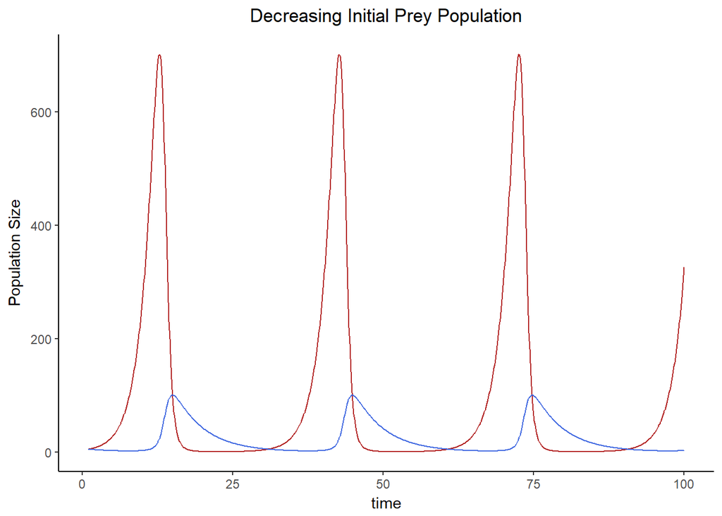

```r
# simulate dynamics by resetting parameters and intitial conditions
y = c(5,5)
p = c(0.5,0.02,0.1,0.2)
times=seq(from=1,to=100,by=0.1)

# Simulate the model using ode
modelSim=ode(y=y,times=times,func=predPreySim,parms=p)
colnames(modelSim)[2] <- "herbivore"
colnames(modelSim)[3] <- "predator"

# save model as a data frame for plotting purposes
modelSim2 <- as.data.frame(modelSim)

# plot simulation
ggplot(data=modelSim2) + geom_line(aes(x=time,y=herbivore),color="firebrick")+geom_line(aes(x=time,y=predator),color="royalblue")+theme_classic()+ylab("Population Size")+ggtitle("Decreasing Initial Prey Population")+theme(plot.title = element_text(hjust = 0.5))
```

```r
#show result summary of the data frame
summary(modelSim)
```

```
##           herbivore   predator
## Min.      0.6326619   1.952785
## 1st Qu.   1.4337351   2.905456
## Median   10.1132523   8.216084
## Mean     97.7414364  22.871279
## 3rd Qu.  94.6878219  32.804991
## Max.    701.7623894 100.467088
## N       991.0000000 991.000000
## sd      177.0075387  28.422647
```

The above two models changed the number of prey from 25 to 125 and 5, respectively. Interestingly, changing the prey number does not change much of the overall model. There are some slight changes in overall min/max of predator/prey, however the frequency does not seem to change at all. Interestingly, decreasing the inital number of prey increased the maximum number of prey and predators. The relative numbers between the predator and prey does not change much.

### Changing the number of predators

Now let’s do the same thing for the pedators as we did for the prey above. Change predator initial values from 5 to 1.

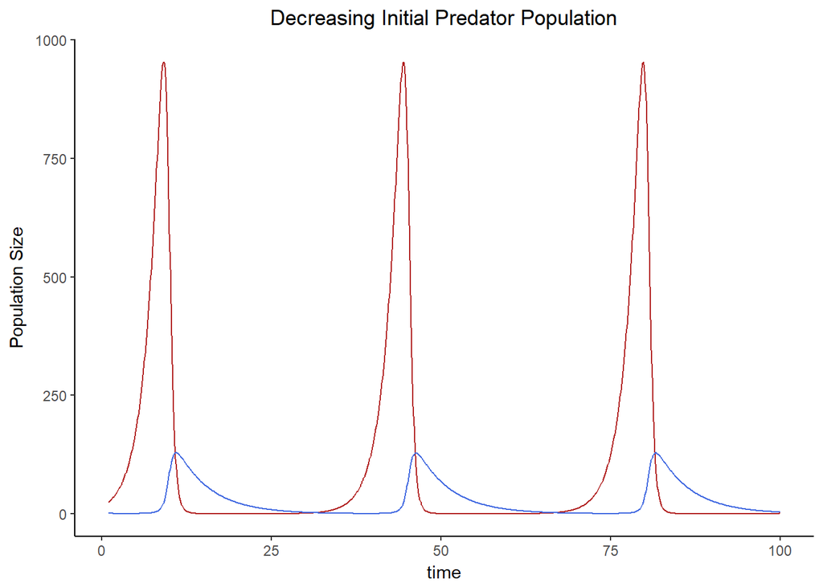

```r
# simulate dynamics by resetting parameters and intitial conditions
y = c(25,1)
p = c(0.5,0.02,0.1,0.2)
times=seq(from=1,to=100,by=0.1)

# Simulate the model using ode
modelSim=ode(y=y,times=times,func=predPreySim,parms=p)
colnames(modelSim)[2] <- "herbivore"
colnames(modelSim)[3] <- "predator"

# save model as a data frame for plotting purposes
modelSim2 <- as.data.frame(modelSim)

# plot simulation
ggplot(data=modelSim2) + geom_line(aes(x=time,y=herbivore),color="firebrick")+geom_line(aes(x=time,y=predator),color="royalblue")+theme_classic()+ylab("Population Size")+ggtitle("Decreasing Initial Predator Population")+theme(plot.title = element_text(hjust = 0.5))
```

```r
#show result summary of the data frame
summary(modelSim)
```

```
##            herbivore    predator
## Min.      0.06872585   0.7681323
## 1st Qu.   0.15660691   1.7932943
## Median    1.50851963   8.6631537
## Mean    106.43758841  26.5960674
## 3rd Qu.  63.43020431  37.5351994
## Max.    953.84907677 128.8241713
## N       991.00000000 991.0000000
## sd      227.67255575  35.6732609
```

Change predator from 5 to 25

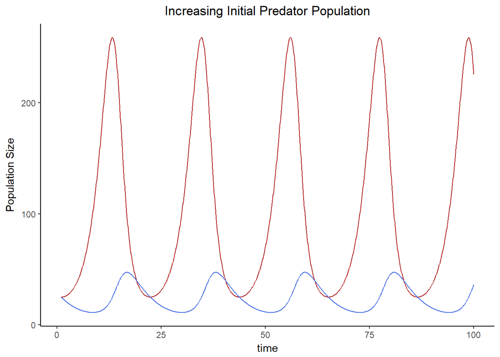

```r
# simulate dynamics by resetting parameters and intitial conditions
y = c(25,25)
p = c(0.5,0.02,0.1,0.2)
times=seq(from=1,to=100,by=0.1)

# Simulate the model using ode
modelSim=ode(y=y,times=times,func=predPreySim,parms=p)
colnames(modelSim)[2] <- "herbivore"
colnames(modelSim)[3] <- "predator"

# save model as a data frame for plotting purposes
modelSim2 <- as.data.frame(modelSim)

# plot simulation
ggplot(data=modelSim2) + geom_line(aes(x=time,y=herbivore),color="firebrick")+geom_line(aes(x=time,y=predator),color="royalblue")+theme_classic()+ylab("Population Size")+ggtitle("Increasing Initial Predator Population")+theme(plot.title = element_text(hjust = 0.5))
```

```r
#show result summary of the data frame
summary(modelSim)
```

```
##         herbivore  predator
## Min.     25.00000  11.12827
## 1st Qu.  32.82907  13.07874
## Median   67.63201  19.72100
## Mean    101.89641  23.89643
## 3rd Qu. 165.16061  33.56128
## Max.    258.66607  47.30765
## N       991.00000 991.00000
## sd       79.45680  12.04776
```

Unlike changing the intial number of prey, changing the inital number of predators dramatically changes the model ouptut. For starters, the frequency for both prey/predator are decreased/increased when the inital predator count is decreased/increased. Additionally, the inital number of predators seems to have a bigger impact on both max/min numbers of both predator/prey. The relative numbers between the predator/prey does not change much.

### Changing the prey birthrate

Change prey birthrate from 0.5 to 0.1 (and time to 200)

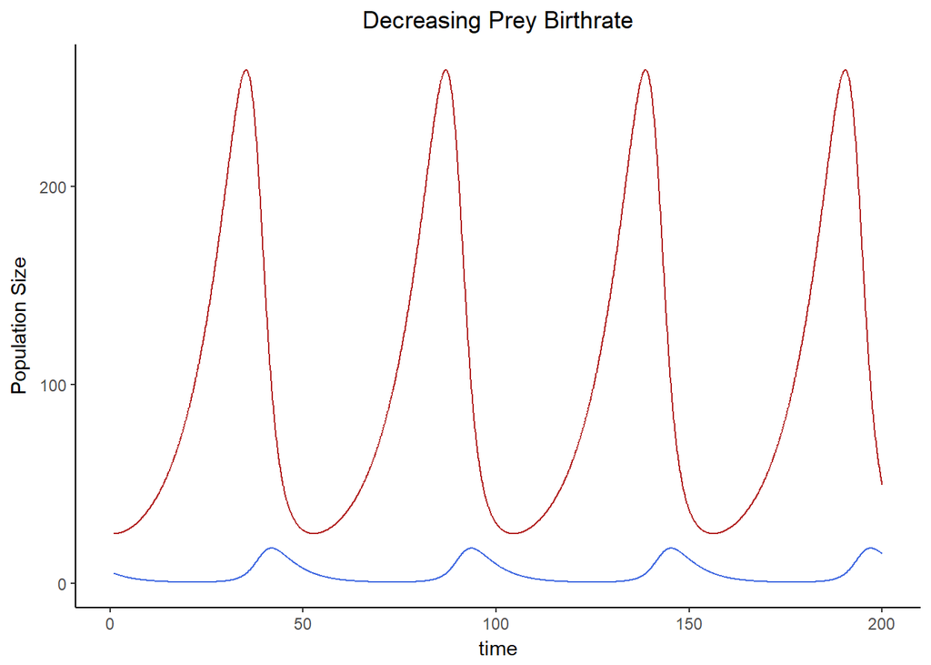

```r
# simulate dynamics by resetting parameters and intitial conditions
y = c(25,5)
p = c(0.1,0.02,0.1,0.2)
times=seq(from=1,to=200,by=0.1)

# Simulate the model using ode
modelSim=ode(y=y,times=times,func=predPreySim,parms=p)
colnames(modelSim)[2] <- "herbivore"
colnames(modelSim)[3] <- "predator"

# save model as a data frame for plotting purposes
modelSim2 <- as.data.frame(modelSim)

# plot simulation
ggplot(data=modelSim2) + geom_line(aes(x=time,y=herbivore),color="firebrick")+geom_line(aes(x=time,y=predator),color="royalblue")+theme_classic()+ylab("Population Size")+ggtitle("Decreasing Prey Birthrate")+theme(plot.title = element_text(hjust = 0.5))
```

```r
#show result summary of the data frame
summary(modelSim)
```

```
##          herbivore     predator
## Min.      24.99999    0.5784130
## 1st Qu.   34.98699    0.8090509
## Median    72.61223    2.0053024
## Mean     102.69778    4.8304693
## 3rd Qu.  161.48185    7.2861356
## Max.     258.66634   17.6770091
## N       1991.00000 1991.0000000
## sd        77.14174    5.4445853
```

Change prey birthrate from 0.5 to 2.5

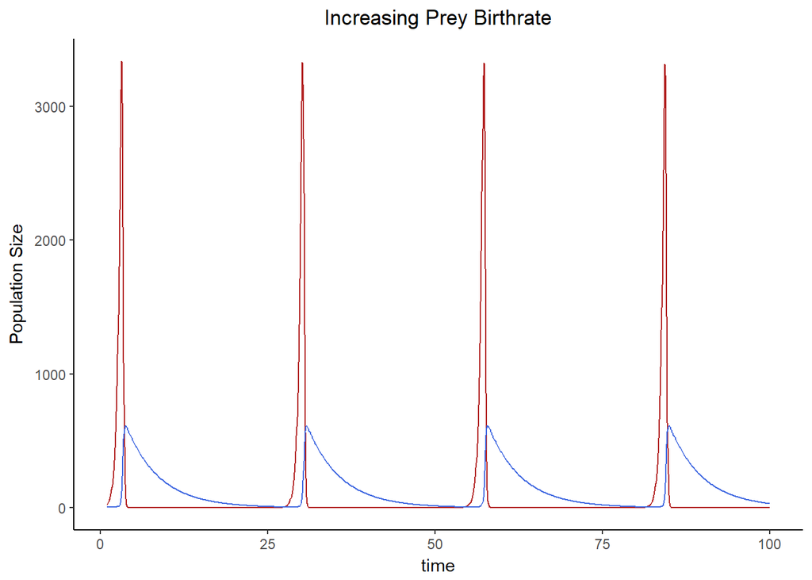

```r
# simulate dynamics by resetting parameters and intitial conditions
y = c(25,5)
p = c(2.5,0.02,0.1,0.2)
times=seq(from=1,to=100,by=0.1)

# Simulate the model using ode
modelSim=ode(y=y,times=times,func=predPreySim,parms=p)
colnames(modelSim)[2] <- "herbivore"
colnames(modelSim)[3] <- "predator"

# save model as a data frame for plotting purposes
modelSim2 <- as.data.frame(modelSim)

# plot simulation
ggplot(data=modelSim2) + geom_line(aes(x=time,y=herbivore),color="firebrick")+geom_line(aes(x=time,y=predator),color="royalblue")+theme_classic()+ylab("Population Size")+ggtitle("Increasing Prey Birthrate")+theme(plot.title = element_text(hjust = 0.5))
```

```r
#show result summary of the data frame
summary(modelSim)
```

```
##            herbivore   predator
## Min.    9.095405e-12   4.693959
## 1st Qu. 9.918855e-11  15.682254
## Median  8.119030e-08  60.056245
## Mean    1.090432e+02 135.143648
## 3rd Qu. 1.259708e-02 199.813250
## Max.    3.338002e+03 613.872554
## N       9.910000e+02 991.000000
## sd      4.676766e+02 161.949298
```

### Changing predator attack rate

Change predator attack rate from 0.02 to 0.1

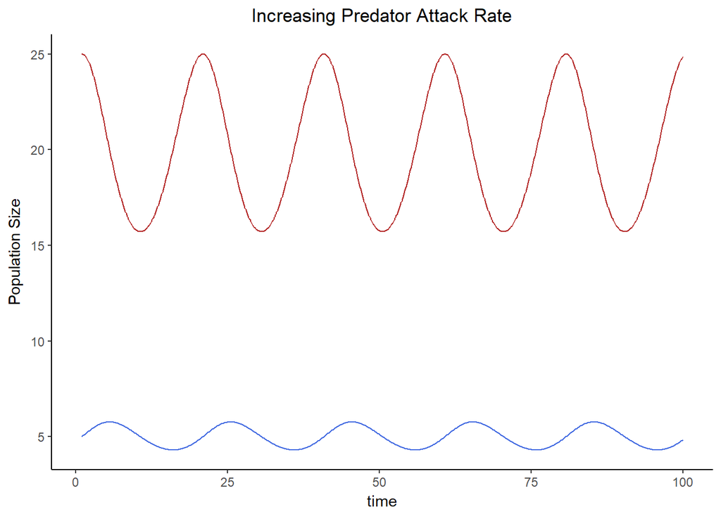

```r
# simulate dynamics by resetting parameters and intitial conditions
y = c(25,5)
p = c(0.5,0.1,0.1,0.2)
times=seq(from=1,to=100,by=0.1)

# Simulate the model using ode
modelSim=ode(y=y,times=times,func=predPreySim,parms=p)
colnames(modelSim)[2] <- "herbivore"
colnames(modelSim)[3] <- "predator"

# save model as a data frame for plotting purposes
modelSim2 <- as.data.frame(modelSim)

# plot simulation
ggplot(data=modelSim2) + geom_line(aes(x=time,y=herbivore),color="firebrick")+geom_line(aes(x=time,y=predator),color="royalblue")+theme_classic()+ylab("Population Size")+ggtitle("Increasing Predator Attack Rate")+theme(plot.title = element_text(hjust = 0.5))
```

```r
#show result summary of the data frame
summary(modelSim)
```

```
##          herbivore    predator
## Min.     15.715773   4.3024738
## 1st Qu.  16.744698   4.4830608
## Median   19.618941   4.9686235
## Mean     19.972108   5.0004559
## 3rd Qu.  23.192277   5.5175409
## Max.     25.000000   5.7691227
## N       991.000000 991.0000000
## sd        3.264623   0.5194991
```

Change predator attack rate from 0.02 to 0.004

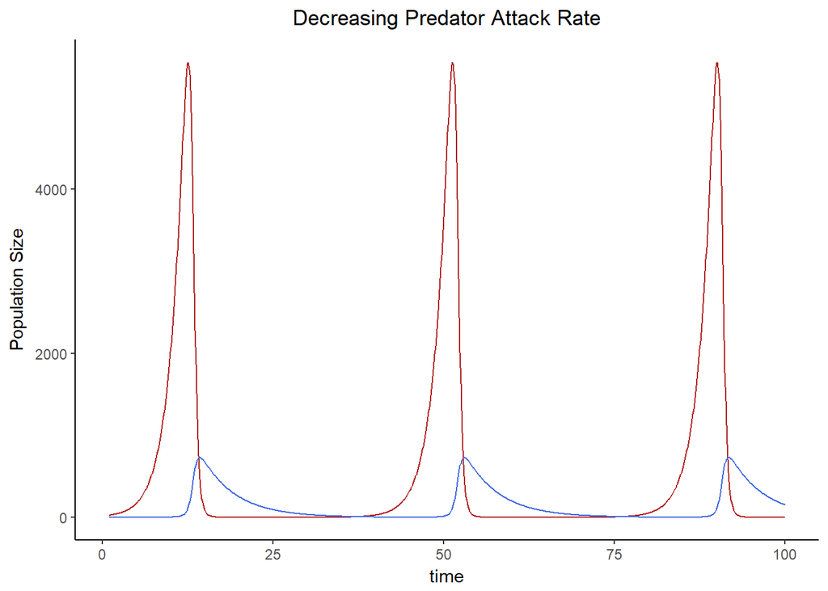

```r
# simulate dynamics by resetting parameters and intitial conditions
y = c(25,5)
p = c(0.5,0.004,0.1,0.2)
times=seq(from=1,to=100,by=0.1)

# Simulate the model using ode
modelSim=ode(y=y,times=times,func=predPreySim,parms=p)
colnames(modelSim)[2] <- "herbivore"
colnames(modelSim)[3] <- "predator"

# save model as a data frame for plotting purposes
modelSim2 <- as.data.frame(modelSim)

# plot simulation
ggplot(data=modelSim2) + geom_line(aes(x=time,y=herbivore),color="firebrick")+geom_line(aes(x=time,y=predator),color="royalblue")+theme_classic()+ylab("Population Size")+ggtitle("Decreasing Predator Attack Rate")+theme(plot.title = element_text(hjust = 0.5))
```

```r
#show result summary of the data frame
summary(modelSim)
```

```
##            herbivore   predator
## Min.       0.0839023   2.156335
## 1st Qu.    0.3204918   4.319488
## Median     9.4939063  27.365309
## Mean     585.7889308 139.188351
## 3rd Qu.  313.3331253 203.998745
## Max.    5549.1553765 730.282173
## N        991.0000000 991.000000
## sd      1287.3686222 202.618168
```

Changing predator attack rate has significant effects on the overall model. Both the max/min and frequecy of predator/prey are significantly effected. Increasing the attack rate significantly decreases both the number of predators and prey and also increases the frequency of both predator/prey cycle, whilst decreasing the attack rate does the opposite. Additonally, decreasing the attack rate brings the prey to near extinction levels, as evidenced by the 0.08 minimum of prey, perhaps making it an unsustainable model. However, the relationship between the means does not change much from the original model (~1:4 ratio for predator:prey).

### Changing conversion efficiency

Change conversion efficiency from 0.1 to 0.5

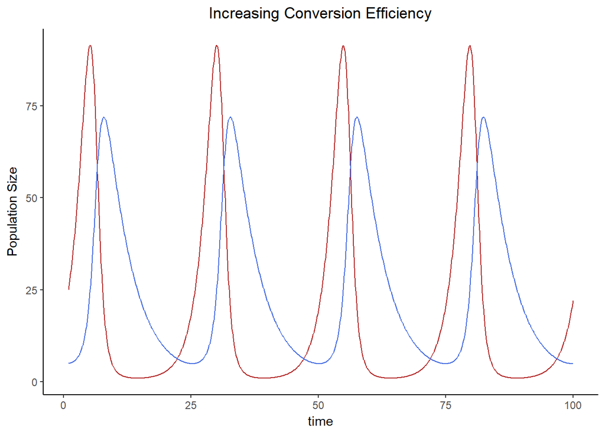

```r
# simulate dynamics by resetting parameters and intitial conditions
y = c(25,5)
p = c(0.5,0.02,0.5,0.2)
times=seq(from=1,to=100,by=0.1)

# Simulate the model using ode
modelSim=ode(y=y,times=times,func=predPreySim,parms=p)
colnames(modelSim)[2] <- "herbivore"
colnames(modelSim)[3] <- "predator"

# save model as a data frame for plotting purposes
modelSim2 <- as.data.frame(modelSim)

# plot simulation
ggplot(data=modelSim2) + geom_line(aes(x=time,y=herbivore),color="firebrick")+geom_line(aes(x=time,y=predator),color="royalblue")+theme_classic()+ylab("Population Size")+ggtitle("Increasing Conversion Efficiency")+theme(plot.title = element_text(hjust = 0.5))
```

```r
#show result summary of the data frame
summary(modelSim)
```

```
##           herbivore   predator
## Min.      0.9950496   4.933426
## 1st Qu.   1.5542510   7.059209
## Median    5.2672934  15.703786
## Mean     19.9923981  25.043921
## 3rd Qu.  28.4812166  39.363239
## Max.     91.3990109  71.922212
## N       991.0000000 991.000000
## sd       27.1966963  21.480734
```

Change conversion efficiency from 0.1 to 0.02

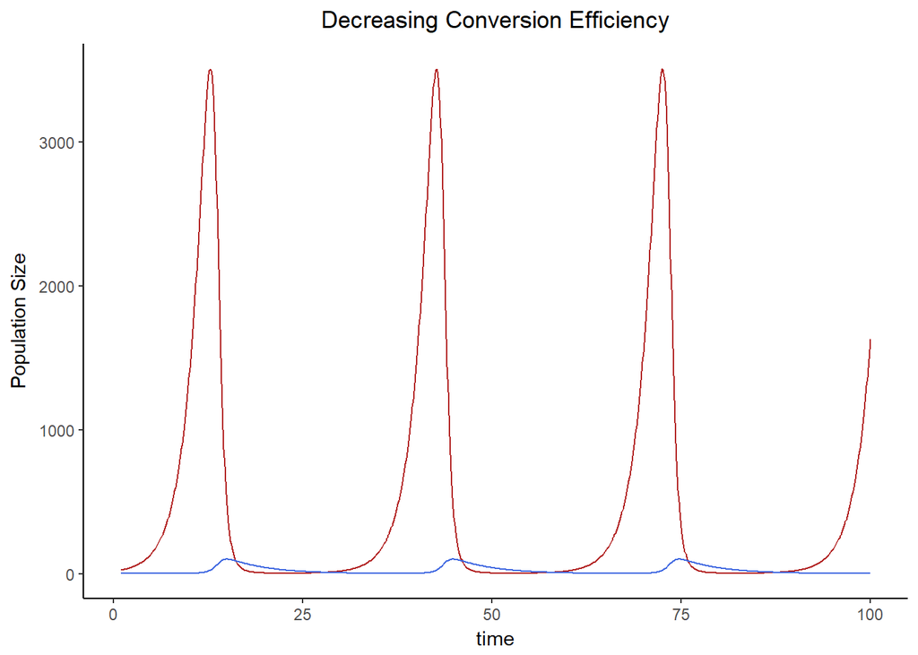

```r
# simulate dynamics by resetting parameters and intitial conditions
y = c(25,5)
p = c(0.5,0.02,0.02,0.2)
times=seq(from=1,to=100,by=0.1)

# Simulate the model using ode
modelSim=ode(y=y,times=times,func=predPreySim,parms=p)
colnames(modelSim)[2] <- "herbivore"
colnames(modelSim)[3] <- "predator"

# save model as a data frame for plotting purposes
modelSim2 <- as.data.frame(modelSim)

# plot simulation
ggplot(data=modelSim2) + geom_line(aes(x=time,y=herbivore),color="firebrick")+geom_line(aes(x=time,y=predator),color="royalblue")+theme_classic()+ylab("Population Size")+ggtitle("Decreasing Conversion Efficiency")+theme(plot.title = element_text(hjust = 0.5))
```

```r
#show result summary of the data frame
summary(modelSim)
```

```
##           herbivore   predator
## Min.       3.163315   1.952785
## 1st Qu.    7.168682   2.905456
## Median    50.566255   8.216081
## Mean     488.707225  22.871278
## 3rd Qu.  473.439118  32.804981
## Max.    3508.812000 100.467086
## N        991.000000 991.000000
## sd       885.037682  28.422646
```

Changing conversion efficiency also changes min/max, frequency, and predator/prey relationships. However, the most interesting aspect of changing the conversion efficency is the change in relative means between the prey/predator relationship. Increasing conversion efficiency brings the relative number of prey much closer to the relative mean of the predator, as would be expected because the predator can more efficiently convert the prey into momre predators.

### Changing predator death rate

Change predator death rate from 0.2 to 1

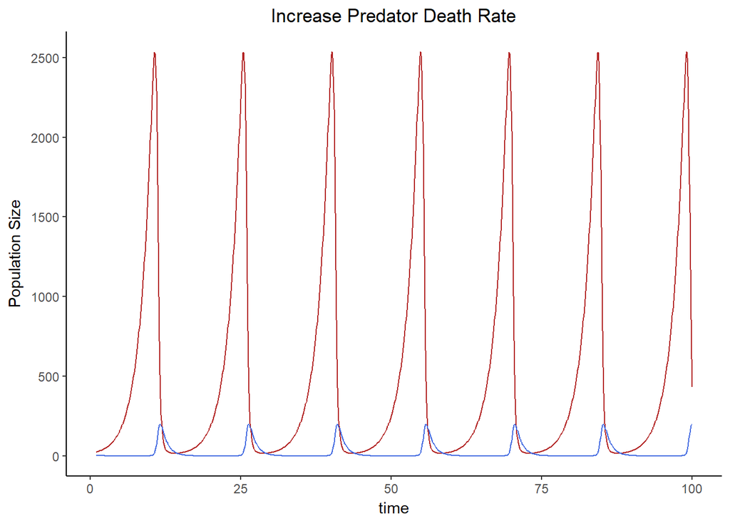

```r
# simulate dynamics by resetting parameters and intitial conditions
y = c(25,5)
p = c(0.5,0.02,0.1,1)
times=seq(from=1,to=100,by=0.1)

# Simulate the model using ode
modelSim=ode(y=y,times=times,func=predPreySim,parms=p)
colnames(modelSim)[2] <- "herbivore"
colnames(modelSim)[3] <- "predator"

# save model as a data frame for plotting purposes
modelSim2 <- as.data.frame(modelSim)

# plot simulation
ggplot(data=modelSim2) + geom_line(aes(x=time,y=herbivore),color="firebrick")+geom_line(aes(x=time,y=predator),color="royalblue")+theme_classic()+ylab("Population Size")+ggtitle("Increase Predator Death Rate")+theme(plot.title = element_text(hjust = 0.5))
```

```r
#show result summary of the data frame
summary(modelSim)
```

```
##          herbivore     predator
## Min.      16.39540   0.06861493
## 1st Qu.   36.67678   0.14542813
## Median   154.09082   1.00662302
## Mean     518.29438  23.64104318
## 3rd Qu.  722.83426  15.08256137
## Max.    2536.99386 199.42709869
## N        991.00000 991.00000000
## sd       707.82100  48.74699762
```

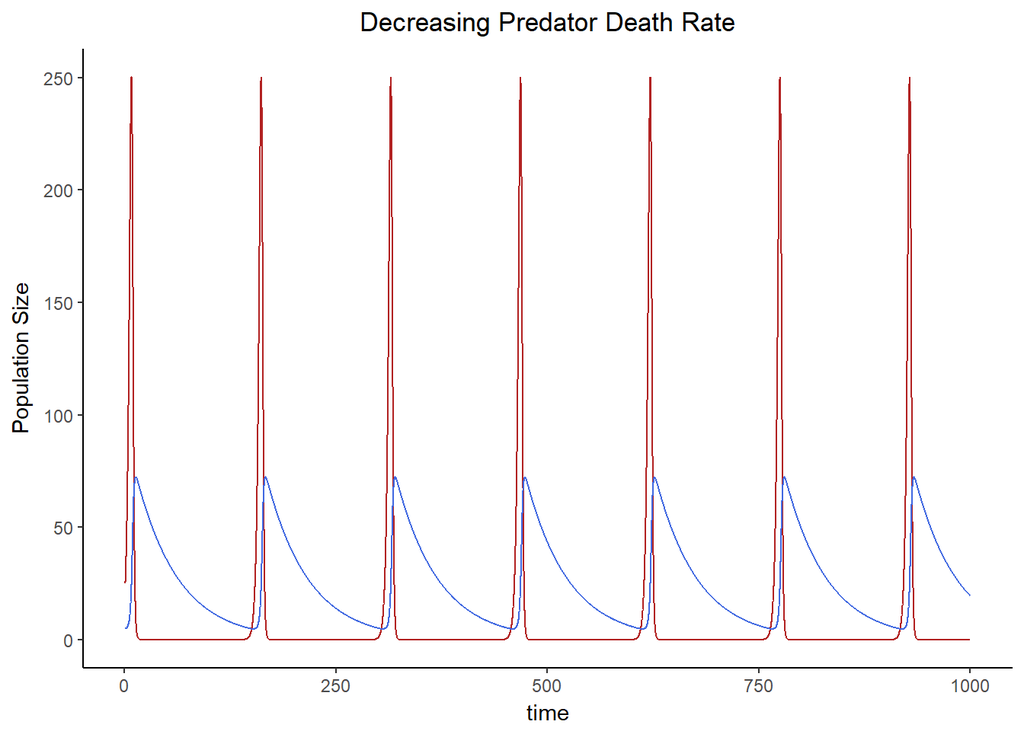

```r
# simulate dynamics by resetting parameters and intitial conditions
y = c(25,5)
p = c(0.5,0.02,0.1,0.02)
times=seq(from=1,to=1000,by=0.1)

# Simulate the model using ode
modelSim=ode(y=y,times=times,func=predPreySim,parms=p)
colnames(modelSim)[2] <- "herbivore"
colnames(modelSim)[3] <- "predator"

# save model as a data frame for plotting purposes
modelSim2 <- as.data.frame(modelSim)

# plot simulation
ggplot(data=modelSim2) + geom_line(aes(x=time,y=herbivore),color="firebrick")+geom_line(aes(x=time,y=predator),color="royalblue")+theme_classic()+ylab("Population Size")+ggtitle("Decreasing Predator Death Rate")+theme(plot.title = element_text(hjust = 0.5))
```

```r
#show result summary of the data frame
summary(modelSim)
```

```
##            herbivore    predator
## Min.    3.340911e-09    4.856713
## 1st Qu. 1.776776e-08    9.078601
## Median  3.437706e-06   19.836287
## Mean    1.068199e+01   26.101291
## 3rd Qu. 1.702700e-02   39.313460
## Max.    2.503980e+02   72.404377
## N       9.991000e+03 9991.000000
## sd      4.043063e+01   19.789750
```

### Conclusion

Overall, all of the state variable and parameters have some effect on the model, whether they change the max/min of the prey/predator, change the overall frequency, change the rate of increase/decrease, or change the relative means of the two populations. What is interesting to note is the models in which the predator/prey minimun numbers reach <1. Realistically, it seems impossible to have half a predator or half a prey, suggesting these models are unsustainable. This suggests, that especially when changing the parameters, one must be careful that the parameters are not changed significantly since the model may become unrealistic, unless that is the purpose.

### Questions

##### What can you say about the “role” of each parameter?

##### What is the relationship between parameter values and predator-prey cycle length?

Each parameter affects the model in different ways, with some parameters having larger effects than others depending on which parameters you are interested in. Dramatically changing some of the parameters makes the model almost unsustainable, as evidenced by the minimum numbers of prey/predator in each summary statement that are less than 1. Otherwise, however, the role of each parameter is fairly straight forward. For starters, what needs to be understood is that predator/prey relationships are intertwined, as evidenced by their rate equations being dependent on the population size of the other.

The prey birth rate has a significant effect on the number of prey in the model, which inherently makes sense. Since the prey birthrate is the only factor that increases the number of prey (assuming the second factor will always be negative or zero), increaseing/decreasing this number understandably increase/decreases the number of prey. However, increasing the prey birth rate by a factor of five does not increase the number of prey by a factor of five, because the change in the number of prey (dp/dt), is limited by the number of prey also. Since the number of predators is reliant on the number of prey avialable, understandably increaseing the prey birth rate also increases the predator count. However, increasing the prey birthrate causes an exponential increase and sudden crash in population numbers caused by the exponential increase in predator numbers, suggesting that increasing the prey birthrate may be unsustainable. Decreasing the prey birthrate has the opposite effect, however, the model seems more sustainable. Additionally, we do not see the exponential increase and crash of the prey but instead see a more steady increase decrease in prey numbers and a similar trend with the predator numbers. Prey birth rate seems to significantly affect the frequency of the prey/predator model, where decreasing prey birth rate decreases the frequency whilst increasing prey birth rate increases the frequency.

The conversion efficiency is interesting, as it is one of the few parameters that significantly affects the ratios between predator and prey population sizes. Increasing conversion efficiency significantly increases the number of predators relative to the number of prey whilst limiting the population size of the prey, and vice versa. The conversion efficiency does not seem to have a significant effect on the frequency of the predator/prey cycle.

Finally, the predator death rate also has effects as expected. Increasing predator death rate causes a surge in prey numbers until such a point that we see a significant enough population of predators to bring the prey population down. Increasing predator death rate also increases the predator/prey cycle frequency. Decreasing the predator death rate has the opposite effect, where we observe a sudden spike in prey numbers when the predator numbers decrease. Due to the predator lingering (because of their lower death rate), prey essentially go extinct until there are low enough numbers of predators that the prey can recover. The lingering of the predators causes a decrease in frequency of the predator/prey cycle, as expected.

##### What can you say about the role of predators in the simulations?

The role of predators in the simulations is to keep in check the population of prey when the number of prey get too high. Without a limiting constraint on the prey, such as the predator, the prey would hypothetically expand exponentially unless there were to be a limiting resource or outside competition. This fact can be observed from the fact that in any of the given models above, the predator numbers only rise when the prey number rises, which inherently makes sense if we observe the equations. Because in the Lotka-Volterra model the only factor that allows predator numbers to increase is $e*a*P*H$ (assuming $s*P$ is always negative), the number of prey in the model (H) is the limiting factor in the model. And only when the number of predators rises the prey numbers start to decrease, and thus are kept in check. Once the number of prey die down, $e*a*P*H$ goes down and $s*P$ takes over, causing the overall number of predators to decrease.

# Group Project Question 2 - Rosenzweig-MacArthur Model

## Model Description

The Rosenzweig-MacArthur model describes predator-prey dynamics. It is based off of the simpler Lotka-Volterra Model, but it adds two elements:

*Prey become self-limiting in absence of predators.*

*Predator kill density cannot grow indefinitely; there reaches a maximum no matter how large the prey density is.*

## Model Equations

Rosenzweig and MacArthur described the prey population (H) and the predator population (P) with the following equations:

$dh/dt = b*H*(1-alpha*H) - w*H*P/(d + H)$

$dP/dt = e*w*H*P/(d + H) - s*P$

## Qualitative Results

There are three qualitative results for this model:

*1. Prey go to carrying capacity, predators go extinct.*

$H^* = 1/aplha = k$ and $P^* = 0$

*2. Prey and predators coexist in stable equilibrium.*

$H^* = s*d/(e*w - s)$ and $P^* = (b*H^* - b*d*alpha - b*alpha*H^**H^* + d*b)/w$

*3. Prey and predators coexist in an oscillatory manner.*

Let’s begin by writing a function that describes the model:

```r
### Function for Rosenzweig-MacArthur Predator/Prey Equations ###
ddRM <- function (t,y,p){

  #Unpack State Variables
  H = y[1] #Prey
  P = y[2] #Predator

  #Unpack Model Parameters
  b = p[1] #Prey birth rate
  e = p[2] #Conversion efficency of prey to predator
  s = p[3] #Predator death rate
  w = p[4] #Predator attack rate
  d = p[5] #Density of prey when predator's kill rate is 1/2*max
  alpha = p[6] #Prey self-limiting term

  #Defining Rates of Change
  dHdt = b*H*(1 - alpha*H) - w*H/(d + H)*P
  dPdt = e*w*H/(d + H)*P- s*P

  return(list(c(dHdt, dPdt)))
}
```

## Model Solution

Now, we will solve the following initial parameters:

$b = 0.8$

$e = 0.07$

$s = 0.2$

$w = 5$

$d = 400$

$alpha = 0.001$

$H0 = 500$

$P0 = 120$

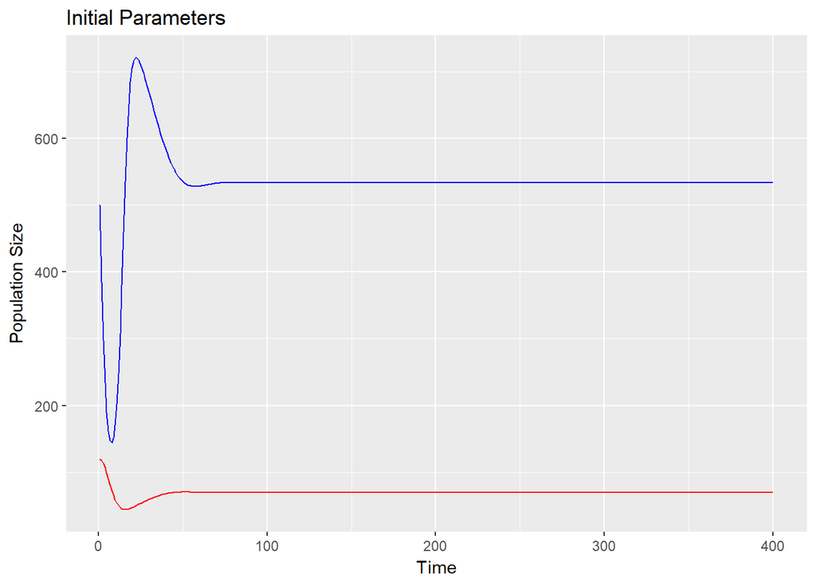

```r
### Defining Initial Parameters ###
b = 0.8
e = 0.07
s = 0.2
w = 5
d = 400
alpha = 0.001
params = c(b, e, s, w, d, alpha)

H0 = 500
P0 = 120
Y0 = c(H0, P0)

times = 1:400

modelSim = ode(y=Y0, times = times, func = ddRM, parms = params)

#Subsetting the Results
modelOutput = data.frame(time=modelSim[,1],H=modelSim[,2],P = modelSim[,3])

#Graphing the Results
ggplot(modelOutput) +
  geom_line(aes(x = time, y = H), colour = "blue") +
  geom_line(aes(x = time, y = P), colour = "red") +
  ggtitle("Initial Parameters") +
  labs(y="Population Size", x = "Time")
```

[figure not shown]

```r
ggplot(modelOutput, aes(H,P)) + geom_point() +
  ggtitle("Predator vs. Prey Population") +
  labs(y="Prey Population Size", x = "Predator Population Size")
```

# Describing Role of Parameters

Let’s now change individual parameters in order to show the role that each one has

## Predator Attack Rate

### Low Attack Rate:

Low attack rate means that predators cannot sustain themselves, and their population goes to zero

Prey population reach self-limiting equilibrium

### High Attack Rate

Predators are able to survive

High attack rate implies that prey will be driven to a small population. Predators can’t survive if prey population is small, so they decreases

As predator population decreases, prey population is able to increase. The cycle repeats

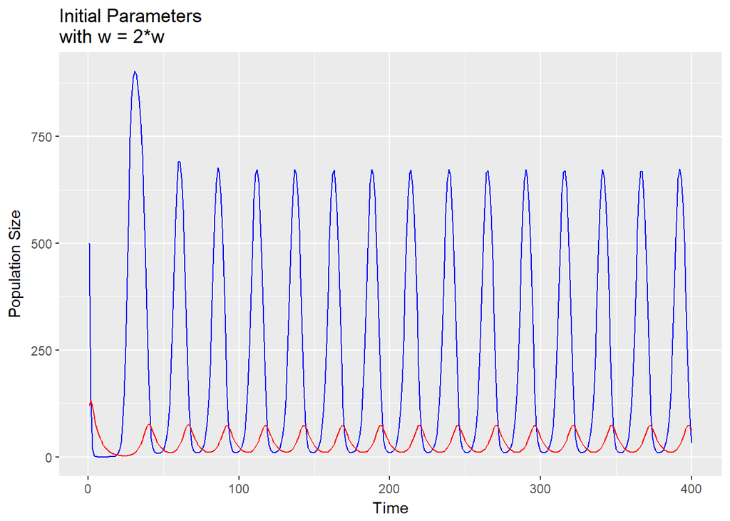

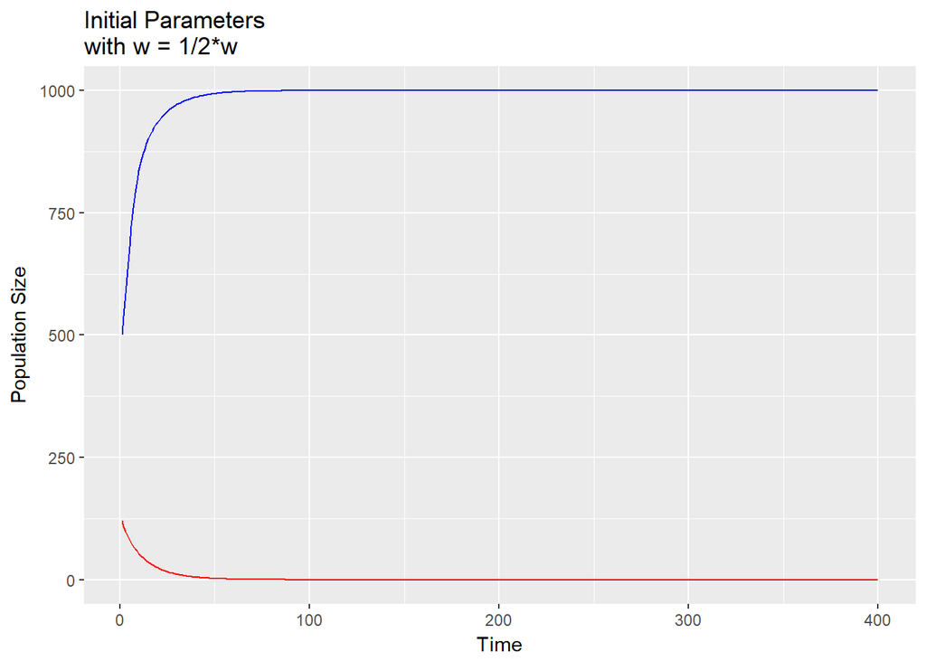

## Prey Denisty to Maximize Predator Attack

### Low d values

Predator population can maximize attack rate more easily

Maximizing attack rate drives prey population down

Small prey population hurts the predators, so predators decrease

The system oscillates

### High d values

Predators cannot reach an attack rate that sustains their population

Predator population goes to zero; prey go to carrying capacity

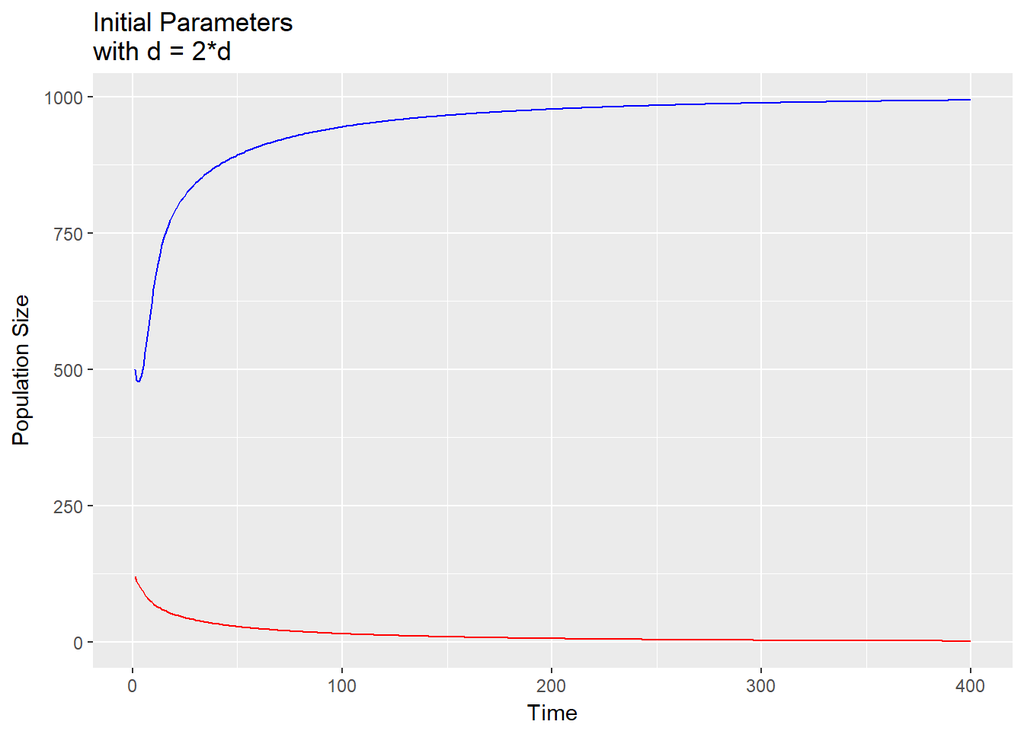

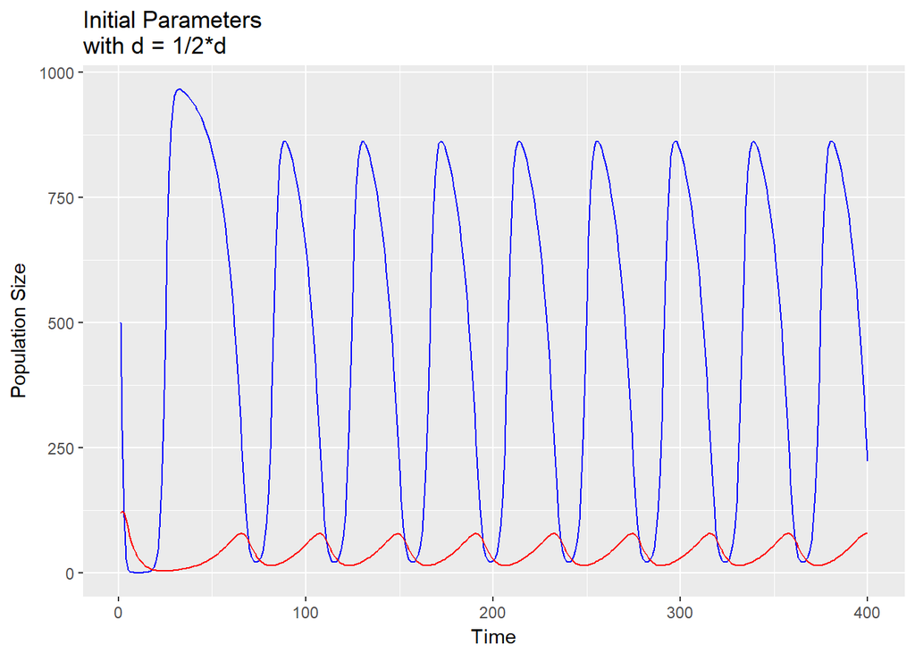

## Carrying Capacity/Alpha (alpha = 1/k)

### Low alpha

Low alpha implies higher carrying capacity of prey

Higher carrying capacity implies higher population; this sustains predators

System oscillates

### High alpha

Carrying Capacity is lower, and predators cannot sustain themseleves when there are less prey

Prey go to their carrying capacity

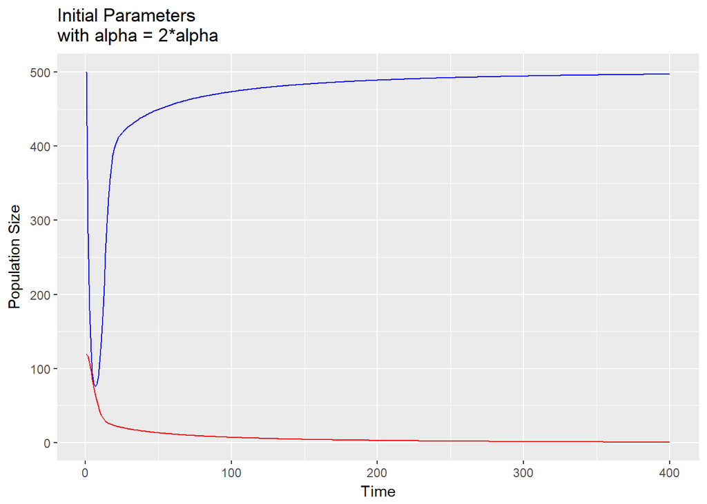

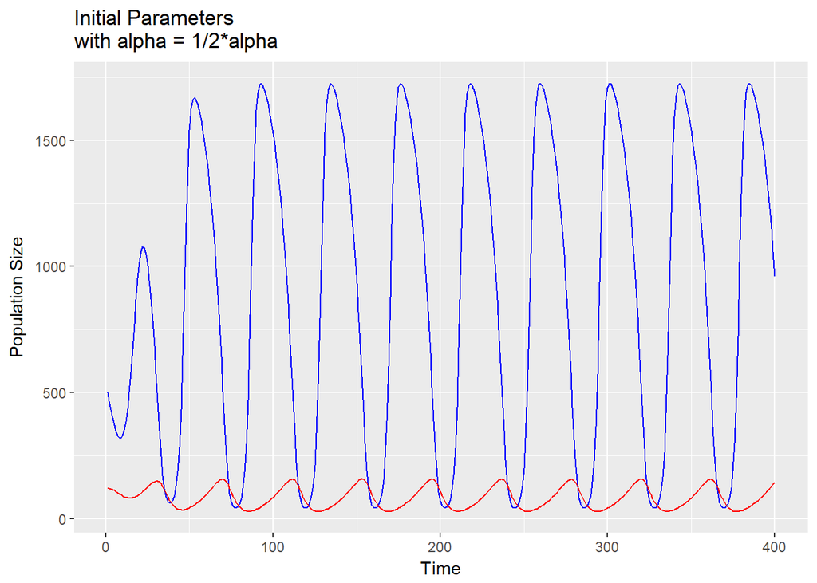

## Prey Birthrate

### At low birth rate (0.2-1.6)

Prey and Predator population will decrease initially before increase in prey then increase in predator to equilibrium.

Predator death due to starvation allowing Prey population to increase to self-limiting density. Increase in Prey population allows Predator population to increase to capacity while Prey population decreases to equilibrium

### At high birth rate (2.0-3.2)

Prey birthrate increases to self-limiting density before Predator decreases Prey rate to equilibrium

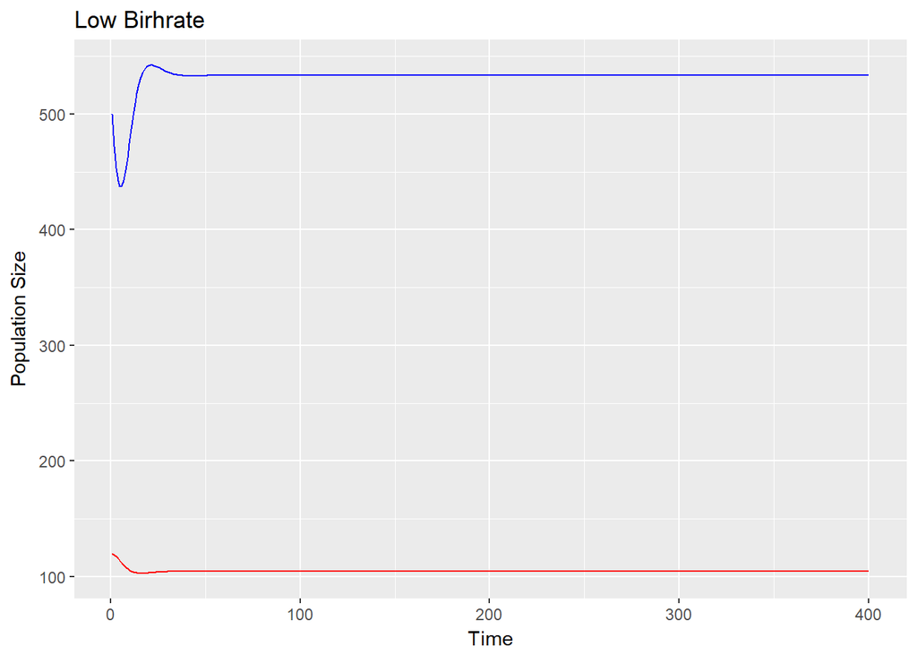

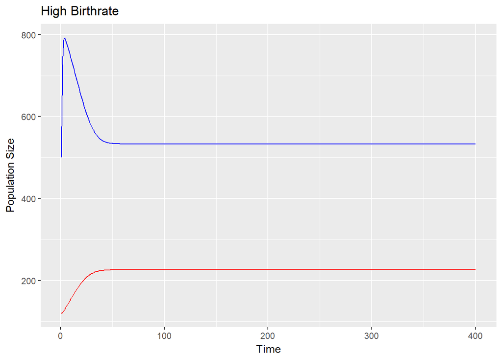

## Conversion efficiency of Prey to Predator

### Low efficiency conversion (0.0175-0.0525)

Rate of Predator decreases because of efficiency to convert energy to more Predator, the population will decrease to 0 as Prey population increases to self-limiting density. Rate to capacity determined by other parameters in the function

### Medium efficiency conversion and mutual equilibrium (0.07-0.0875)

Rate of Prey and Predator will oscillate.

Prey population drops as Predator starts consuming. Predator reaches a population size that is not sustained by the amount of Prey and population will decrease. Prey will bounce back and cycle will begin again until reaching a stable equilibrium.

### High efficiency conversion (0.1050-0.28)

Rate of exchange from Prey to Predator occurs too quickly.

System will change from decreasing Prey and increasing Predator until Predator density is reached. Predators will decrease from starvation or lack of Prey to support system until Prey numbers bounch back. Increase in efficiency will increase maximum capacity of predator

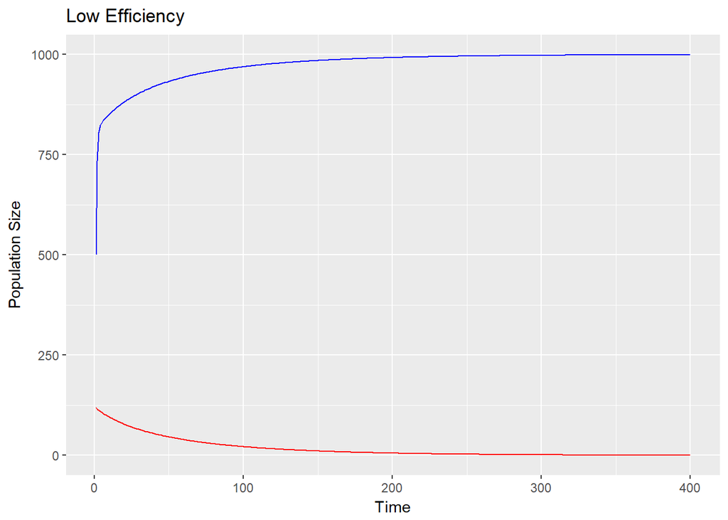

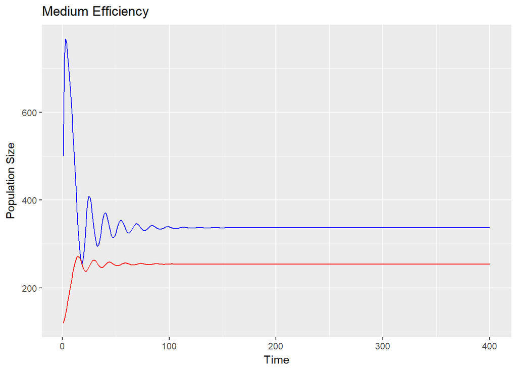

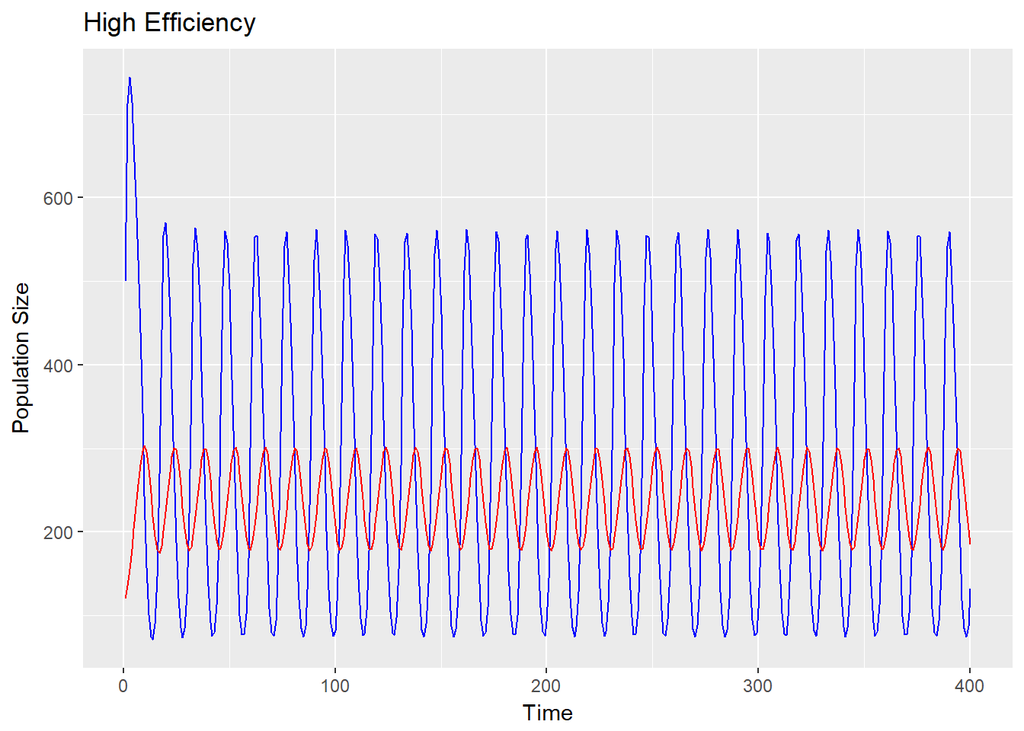

## Predator Death Rate

### Low Death Rate (0.05-0.2)

Low death rate leads to depletion of Prey population

Decrease in Prey population decreases Predator density limit. Oscillation of both population until equilibrium is reached, or will continue to oscillate between capacity and 0

#### High Death Rate (0.25-0.8)

High death rate results in eradication of Predator and increase of Prey Population to self-limiting density

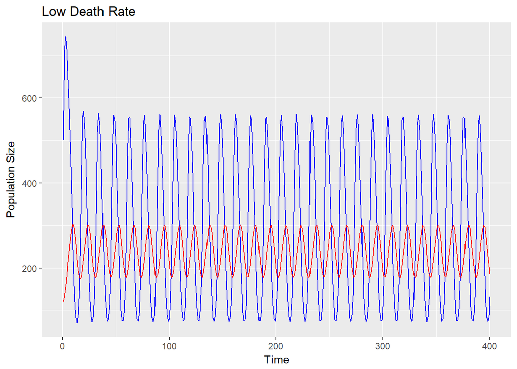

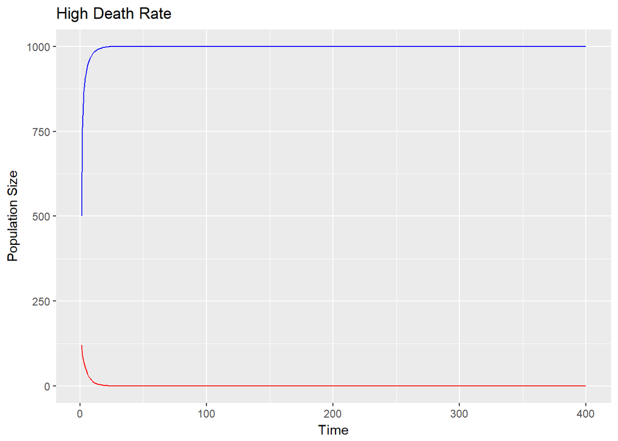

# Question 2 Responses

### How do the dynamics differ from Lotka-Volterra?

Dynamics in R-M models allow for an equilibrium population. The L-V population conistantly oscillates between Prey depletion and Predator starvation to Prey

## What can you say about the role of each parameter, especially what causes the dyamics to differ between the L-V and R-M models?

The extra parameters seen in the R-M model adds complexity that allows for both populations to reach a population size in which co-habitation can be possible within some range of the parameters.

## What is the relationship between parameter values and predator abundance?

# Paradox of Enrichment

Conceptually, higher carrying capacity (lower alpha) should lead to predator stability because more prey will buffer the population from extinction.

However, the RM model shows that there is a negative relationship between prey carrying capacity and predator stability: as alpha decreases (carrying capacity increases), the population of predators becomes less stable. This is termed the *Paradox of Enrichment*. Let’s see some examples of this:

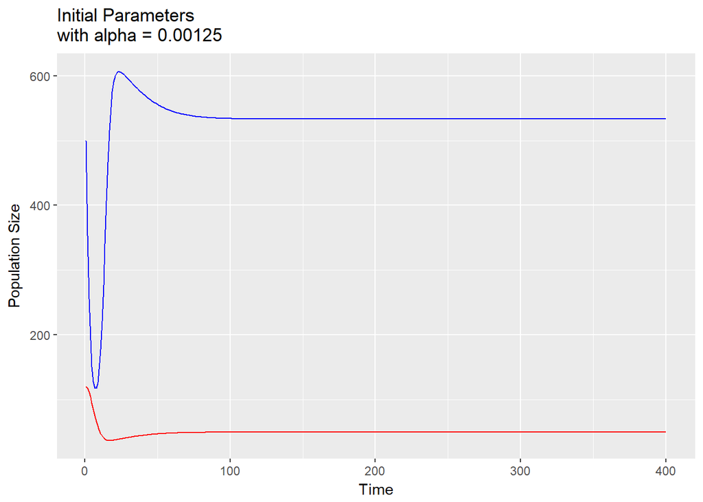

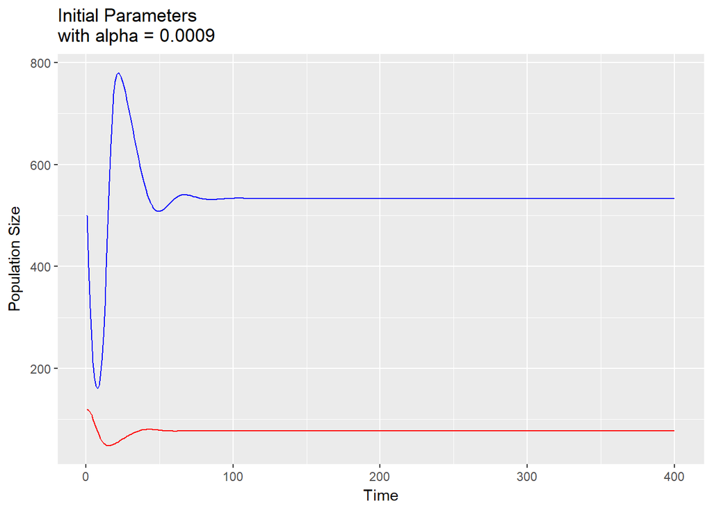

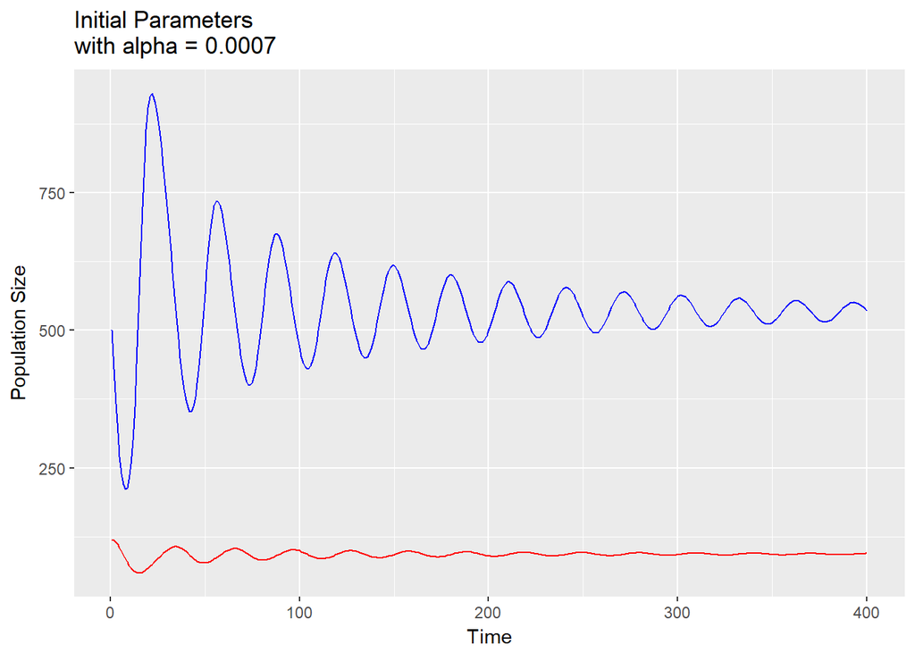

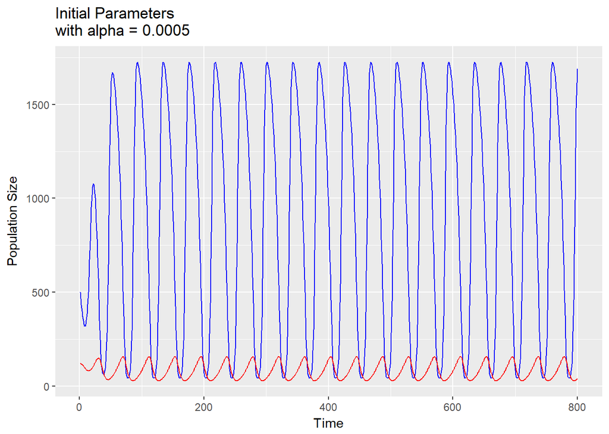

At low carrying capacities, the self-limiting aspect of the prey population leads to a stable equilibrium between predators and prey. However, as carrying capacity increases, a certain stability threshold is passed. Prey population is able to grow to such a point that predators can eat enough prey, driving the prey population down, which in turn drives the predator population down, leading to oscillation.